# STAT 652 Final Project: Customer Churn Classification

Author

Nikhil Kumar

Published

Invalid Date

## STEP : 1 DEFINING THE PROBLEM

The goal of this project is to predict customer churn using the other variables in the dataset.

- Response variable: Churn
- Type of response: binary with two classes No and Yes
- Number of observations: more than 100
- Main scoring metric: ROC AUC
- Other reported metrics: accuracy, precision, recall, and F1 score

The best model will be selected based on the highest ROC AUC. If two models perform very similarly, then F1 score and accuracy will be used to decide which model is better.Step 2: Collect and understand the data

## STEP : 2 COLLECTING AND UNDERSTANDING THE DATA

The dataset contains 7,043 observations and 21 variables. The response variable is Churn and the class distribution shows that about 73.5 percent of customers did not churn, while about 26.5 percent did churn. This means the data is somewhat imbalanced because non churn cases are more common.

The summary statistics show a clear difference between the two groups. Customers who did not churn had much higher average tenure and higher total charges while customers who churned had higher monthly charges on average. This suggests that customers who stay longer are less likely to leave, and customers with higher monthly costs may be more likely to churn.

The contract plot also supports this pattern. Customers with month to month contracts have the highest churn rate while customers with one year and especially two year contracts have much lower churn rates. This means contract type seems to be an important predictor of churn.

```
[1] 7043   21
```

```
 [1] "customerID"       "gender"           "SeniorCitizen"    "Partner"
 [5] "Dependents"       "tenure"           "PhoneService"     "MultipleLines"
 [9] "InternetService"  "OnlineSecurity"   "OnlineBackup"     "DeviceProtection"
[13] "TechSupport"      "StreamingTV"      "StreamingMovies"  "Contract"
[17] "PaperlessBilling" "PaymentMethod"    "MonthlyCharges"   "TotalCharges"
[21] "Churn"
```

```
  Churn    n      prop
1    No 5174 0.7346301
2   Yes 1869 0.2653699
```

```
Rows: 7,043
Columns: 21
$ customerID       <chr> "7590-VHVEG", "5575-GNVDE", "3668-QPYBK", "7795-CFOCW…
$ gender           <fct> Female, Male, Male, Male, Female, Female, Male, Femal…
$ SeniorCitizen    <fct> No, No, No, No, No, No, No, No, No, No, No, No, No, N…
$ Partner          <fct> Yes, No, No, No, No, No, No, No, Yes, No, Yes, No, Ye…
$ Dependents       <fct> No, No, No, No, No, No, Yes, No, No, Yes, Yes, No, No…
$ tenure           <int> 1, 34, 2, 45, 2, 8, 22, 10, 28, 62, 13, 16, 58, 49, 2…
$ PhoneService     <fct> No, Yes, Yes, No, Yes, Yes, Yes, No, Yes, Yes, Yes, Y…
$ MultipleLines    <fct> No phone service, No, No, No phone service, No, Yes, …
$ InternetService  <fct> DSL, DSL, DSL, DSL, Fiber optic, Fiber optic, Fiber o…
$ OnlineSecurity   <fct> No, Yes, Yes, Yes, No, No, No, Yes, No, Yes, Yes, No …
$ OnlineBackup     <fct> Yes, No, Yes, No, No, No, Yes, No, No, Yes, No, No in…
$ DeviceProtection <fct> No, Yes, No, Yes, No, Yes, No, No, Yes, No, No, No in…
$ TechSupport      <fct> No, No, No, Yes, No, No, No, No, Yes, No, No, No inte…
$ StreamingTV      <fct> No, No, No, No, No, Yes, Yes, No, Yes, No, No, No int…
$ StreamingMovies  <fct> No, No, No, No, No, Yes, No, No, Yes, No, No, No inte…
$ Contract         <fct> Month-to-month, One year, Month-to-month, One year, M…
$ PaperlessBilling <fct> Yes, No, Yes, No, Yes, Yes, Yes, No, Yes, No, Yes, No…
$ PaymentMethod    <fct> Electronic check, Mailed check, Mailed check, Bank tr…
$ MonthlyCharges   <dbl> 29.85, 56.95, 53.85, 42.30, 70.70, 99.65, 89.10, 29.7…
$ TotalCharges     <dbl> 29.85, 1889.50, 108.15, 1840.75, 151.65, 820.50, 1949…
$ Churn            <fct> No, No, Yes, No, Yes, Yes, No, No, Yes, No, No, No, N…
```

```
# A tibble: 2 × 4
  Churn mean_tenure mean_monthly mean_total
  <fct>       <dbl>        <dbl>      <dbl>
1 No           37.6         61.3      2555.
2 Yes          18.0         74.4      1532.
```

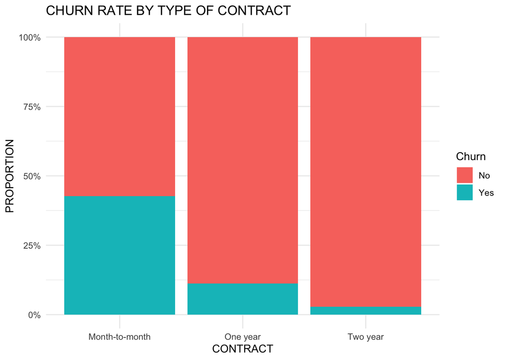

## STEP : 3 PREPAREING THE DATA

In this step I prepared the data for modeling. I converted the categorical variables into factors and handled missing values in TotalCharges. I also treated customerID as an identifier so it would not be used as a predictor in the models.

Next I split the data into training and test sets using an 80 20 split. The training set was used to fit the models and the test set was used to evaluate performance on unseen data. I also used recipes to handle imputation create dummy variables and normalize predictors for models that need numeric inputs.

```
[1] 5634
```

```
[1] 1409
```

- customerID is treated as an identifier, not a predictor.
- Missing TotalCharges values are handled with median imputation.
- Dummy variables and normalization are used for models that need numeric predictors.

## STEP : 4 FITTING AND COMPAREING MODELS

I fit all of the classification models covered in class. These were Null Model, Logistic Regression ,LASSO, k Nearest Neighbors ,Neural Network ,Random Forest ,Boosted C5.0 and Naive Bayes.

The models fit here are:

1. Null Model
2. Logistic Regression
3. Regularized Logistic Regression (LASSO)
4. k-Nearest Neighbors
5. Neural Network
6. Random Forest
7. Boosted C5.0
8. Naive Bayes

```
# A tibble: 8 × 6
  Model                           Accuracy Precision Recall `F1 Score` `ROC AUC`
  <chr>                              <dbl>     <dbl>  <dbl>      <dbl>     <dbl>
1 Boosted C5.0                       0.806     0.662  0.546      0.598     0.841
2 Logistic Regression                0.808     0.669  0.551      0.604     0.839
3 Random Forest                      0.796     0.648  0.511      0.571     0.834
4 Regularized Logistic Regressio…    0.791     0.647  0.465      0.541     0.829
5 k-Nearest Neighbors                0.786     0.610  0.543      0.574     0.820
6 Neural Network                     0.787     0.615  0.529      0.569     0.820
7 Naive Bayes                        0.719     0.482  0.775      0.594     0.817
8 Null Model                         0.735     0      0          0         0.5
```

## VISUALISATION

**ROC CURVES**

```
# A tibble: 6 × 4
  .threshold specificity sensitivity Model
       <dbl>       <dbl>       <dbl> <chr>
1 -Inf          0                  1 Null Model
2    0.265      0                  1 Null Model
3  Inf          1                  0 Null Model
4 -Inf          0                  1 Logistic Regression
5    0.00115    0                  1 Logistic Regression
6    0.00122    0.000966           1 Logistic Regression
```

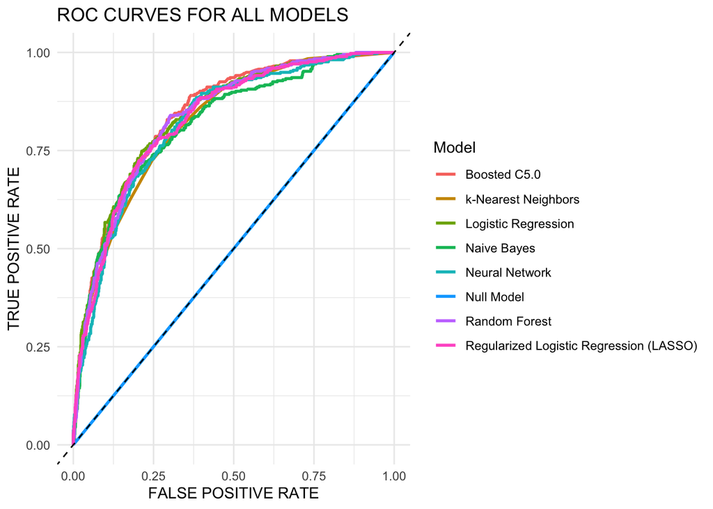

**SEPERATE ROC CURVES**

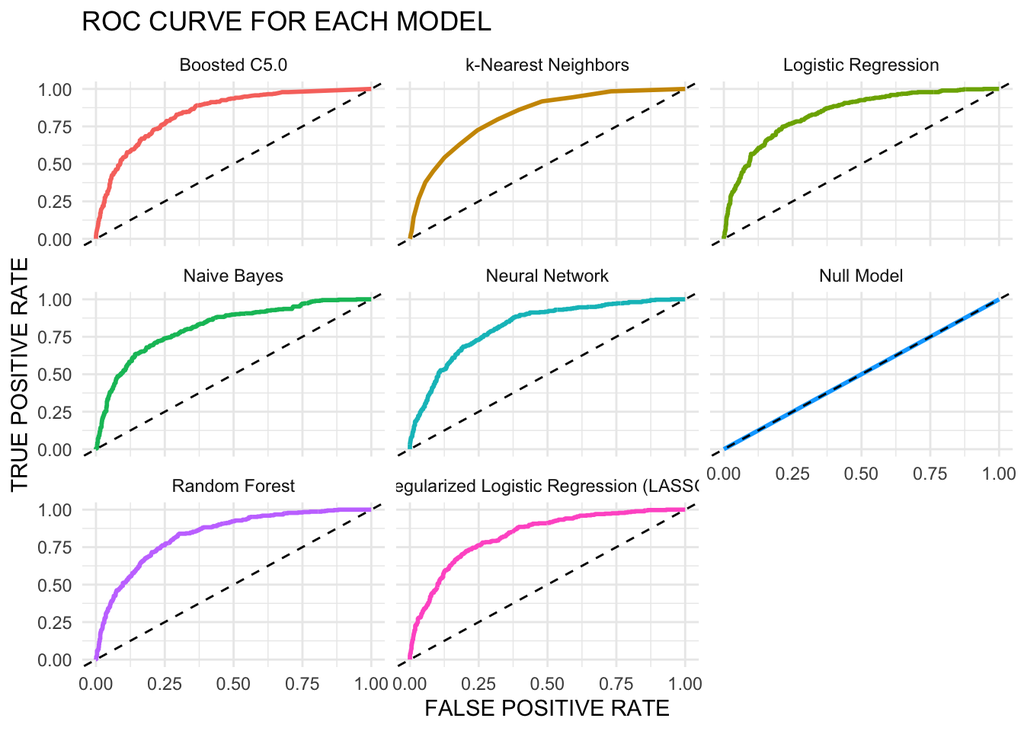

**MODEL PERFORMANCE COMPARISION PLOT**

The plot compares Accuracy Precision Recall F1 Score and ROC AUC for every model. Boosted C5.0 has the best overall performance in the final results. It has the highest overall ranking when ROC AUC is used as the main metric. Logistic Regression and LASSO are also strong models and perform close to the best model. The Null Model is the weakest because it predicts the majority class and does not detect churn well.

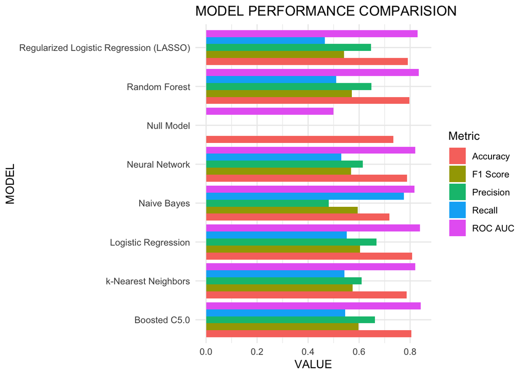

**CONFUSION MATRIX PLOT**

This plot shows how many customers each model classified correctly and incorrectly. Boosted C5.0 and Logistic Regression both do a good job of identifying customers in both classes. Naive Bayes finds more churn cases than some other models but it also makes more mistakes on customers who did not churn. The Null Model predicts almost all customers as non churn so it misses most churn cases. Overall the better models have more correct predictions in both classes and fewer errors.

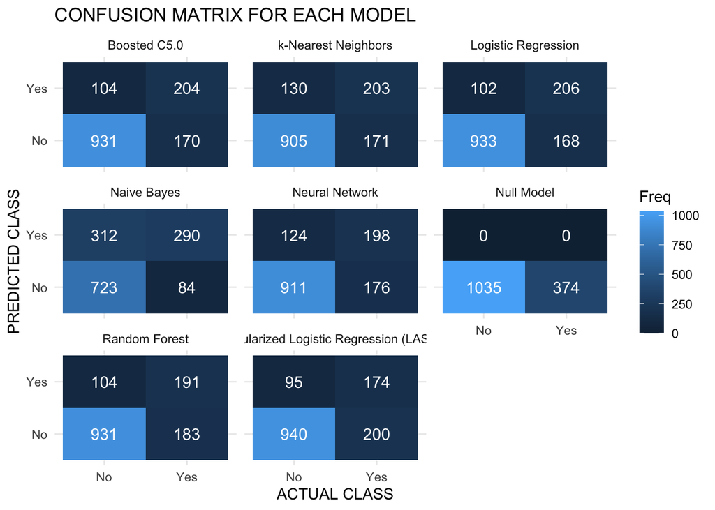

## STEP 5 : CHOOSING THE BEST MODEL AND USING RESULTS

```
[1] "Boosted C5.0"
```

```
          Truth
Prediction  No Yes
       No  931 170
       Yes 104 204
```

```
Based on the comparison table the best model is Boosted C5.0 . The confusion matrix shows that this model correctly predicted 931 customers as No churn and 204 customers as Yes churn. It incorrectly classified 170 churn cases as No churn and 104 non churn cases as Yes churn.
```

```
  customerID predicted_churn churn_probability
1 6713-OKOMC              No        0.33913184
2 9763-GRSKD              No        0.19492943
3 8779-QRDMV             Yes        0.78558755
4 6322-HRPFA              No        0.06091421
5 6827-IEAUQ              No        0.05551779
6 7310-EGVHZ              No        0.28155161
```

This dataset does not include a separate test file. Because of that I created the prediction file using the 20 percent hold out test set from the train test split.

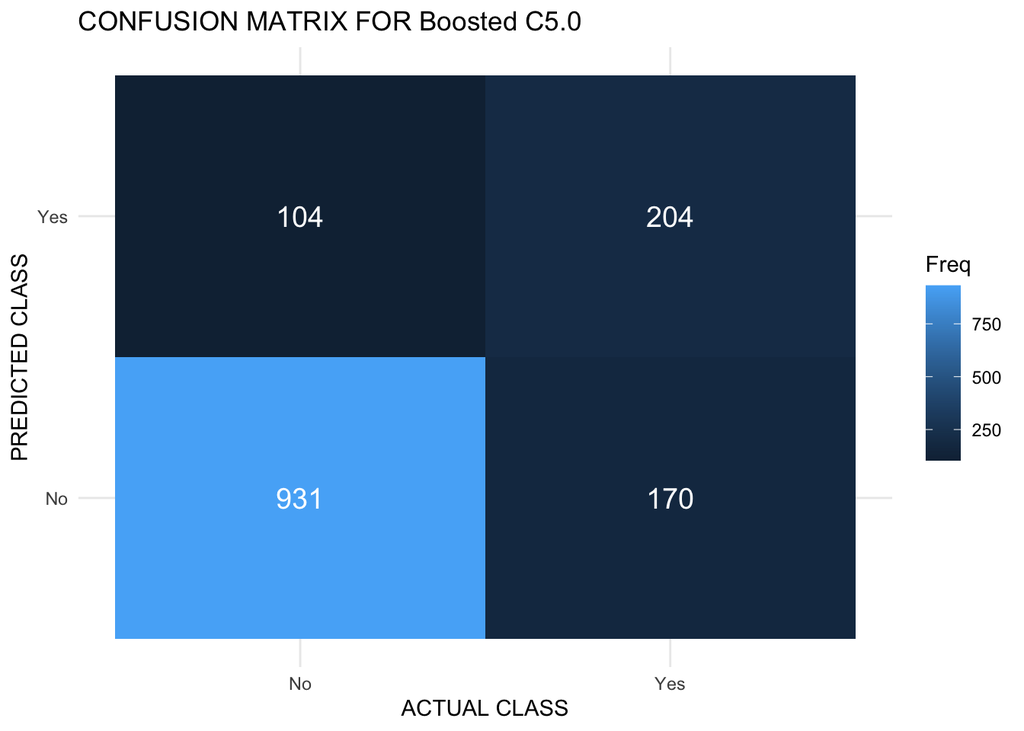

## FINAL ANSWER

Also the dataset meets the requirement of a binary response variable and more than 100 observations

- The analysis is organized using the five step process.
- The project fits all class models used in your course list: Null Model, Logistic Regression, Regularized Logistic Regression (LASSO), k-NN, Neural Network, Random Forest, Boosted C5.0, and Naive Bayes.
- The comparison table reports accuracy, precision, recall, F1 score, and ROC AUC for every model.
- The best model name is Boosted C5.0
- The file customer_churn_test_predictions.csv is created.